# Kdy vztah dvou znaků závisí na třetím?

Interakce numerického a kategoriálního znaku, dvou kategoriálních i dvou numerických znaků

Publikováno

22. září 2026

Upraveno

21. října 2026

## 1 Liší se vztah délky a zadní šířky krunýře mezi samicemi a samci?

Představte si dva kraby se stejně dlouhým krunýřem, jednoho samce a jednu samici. Musí mít stejně širokou zadní část krunýře? A bude případný rozdíl stejný u kratších i delších krabů? To je otázka **vztahu dvou měřených znaků v různých skupinách**, nikoli otázka, které pohlaví je obecně větší.

Proč bychom rozdíl vůbec čekali? Zadní část krunýře leží zhruba nad zadečkem, který má krab podvinutý pod tělem. Samice pod zadečkem nosí oplozená vajíčka, dokud se z nich nevylíhnou larvy. Campbell a Mahon (1974), z jejichž měření budeme vycházet, zjistili, že se samice a samci pobřežních krabů rodu *Leptograpsus* liší poměrem zadní šířky a délky krunýře. Pokud samice s rostoucí velikostí potřebují pro snůšku relativně více místa, mohl by se rozdíl mezi pohlavími s velikostí krabů měnit. Je to biologické očekávání; zda mu odpovídají i naše data, ukážou až měření.

**QuestionHlavní otázka této lekce**

**Je rozdíl v zadní šířce krunýře mezi stejně dlouhou samicí a samcem stejný u menších i větších krabů?**

Zadní šířku budeme odhadovat z délky krunýře a pohlaví. Data jsou pozorovací: samotný rozdíl mezi skupinami nám neřekne, co jej způsobilo.

## 2 Kdy mají dvě přímky stejný sklon?

V minulé lekci jste viděli model se dvěma prediktoryProměnná, pomocí níž vysvětlujeme variabilitu odezvy; v notaci y ~ x je prediktor x.: numerickým znakem a skupinou. Jeho dvě odhadnuté přímky byly rovnoběžné. Jak se podle takového modelu změní rozdíl mezi skupinami, když se numerický prediktor zvětší?

**QuestionVybavte si minulou lekci**

Nakreslete dvě rovnoběžné přímky. Vyberte na ose x dvě různé hodnoty. Je svislá vzdálenost mezi přímkami v obou místech stejná?

**DůležitéMožná odpověď**

Ano. Rovnoběžné přímky mají společný sklonParametr lineárního modelu udávající, o kolik se v průměru liší odezva dvou pozorování, jejichž prediktor se liší o jednu jednotku (při stejných hodnotách ostatních prediktorů)., takže jejich svislá vzdálenost zůstává stejná.

Zkusme zjistit, zda takové omezení dává smysl i pro kraby.

## 3 Výsledky učení

Po prostudování této lekce budete schopni:

- rozpoznat biologickou otázku, ve které vztah jednoho prediktoruProměnná, pomocí níž vysvětlujeme variabilitu odezvy; v notaci y ~ x je prediktor x. k odezvěProměnná, jejíž variabilitu se snažíme vysvětlit nebo předpovědět; v notaci modelu y ~ x je odezva y. závisí na hodnotě nebo úrovni druhého prediktoru;
- fitovat lineární modelStatistický model, v němž je průměrná odezva součtem interceptu a prediktorů násobených koeficienty; lineární je v koeficientech, takže nemusí jít jen o přímku. s interakcíSituace, kdy efekt jednoho prediktoru na odezvu závisí na hodnotě jiného prediktoru. a zobrazit jeho predikceHodnota odezvy, kterou model odhaduje pro nové pozorování nebo pro zvolenou kombinaci prediktorů, která nebyla mezi daty použitými k odhadu modelu. pro kombinace numerických i kategoriálních prediktorů;
- vyložit koeficienty modelu s interakcí jako podmíněné a porovnávat skupiny nebo různé hodnoty prediktoru pomocí predikcí při zvolené hodnotě druhého prediktoru;
- vysvětlit interakci dvou kategoriálních prediktorů jako rozdíl dvou rozdílů;
- omezit závěr na pozorovaný rozsah dat a na souvislost v pozorovacích datech.

## 4 Jeden řádek tabulky představuje jednoho kraba

Použijeme měření krabů z práce Campbell a Mahon (1974). Autoři změřili stejný počet samic a samců dvou barevných forem pobřežního kraba, modré a oranžové, které považují za samostatné druhy rodu *Leptograpsus*. Soubor krabi.csv je součástí materiálů lekce. Pro následující kód jej uložte do složky `data` ve svém projektu v R. Načteme ho a zkontrolujeme názvy a typy sloupců:

```r
# Načteme tabulku všech změřených krabů
data_krabi_vse <-
  read.csv(file = "data/krabi.csv")

# Zkontrolujeme názvy a typy sloupců
str(object = data_krabi_vse)
```

```
'data.frame':   200 obs. of  8 variables:
 $ sp   : chr  "B" "B" "B" "B" ...
 $ sex  : chr  "M" "M" "M" "M" ...
 $ index: int  1 2 3 4 5 6 7 8 9 10 ...
 $ FL   : num  8.1 8.8 9.2 9.6 9.8 10.8 11.1 11.6 11.8 11.8 ...
 $ RW   : num  6.7 7.7 7.8 7.9 8 9 9.9 9.1 9.6 10.5 ...
 $ CL   : num  16.1 18.1 19 20.1 20.3 23 23.8 24.5 24.2 25.2 ...
 $ CW   : num  19 20.8 22.4 23.1 23 26.5 27.1 28.4 27.8 29.3 ...
 $ BD   : num  7 7.4 7.7 8.2 8.2 9.8 9.8 10.4 9.7 10.3 ...
```

Sloupec `sp` označuje barevnou formu (`B` modrá, `O` oranžová), `sex` pohlaví (`F` samice, `M` samec). `CL` je délka krunýře a `RW` šířka jeho zadní části; obě hodnoty jsou v milimetrech. Délka a zadní šířka jsou dvě různé osy téhož krunýře. Ostatní rozměry v této lekci nepotřebujeme.

Pro první otázku vybereme jen kraby **modré formy** a tři potřebné sloupce. Jeden řádek znamená **jednoho změřeného kraba**, ne opakované měřeníData, kde stejná jednotka (jedinec, lokalita) je měřena opakovaně v čase nebo v různých podmínkách; vytváří korelaci mezi pozorováními. téhož jedince.

```r
# Vybereme modrou formu a tři znaky potřebné pro otázku
data_krabi <-
  data_krabi_vse[
    data_krabi_vse$sp == "B",
    c("sex", "CL", "RW")
  ]

# Přejmenujeme sloupce podle toho, co znamenají
names(data_krabi) <-
  c("pohlavi", "delka_krunyre_mm", "zadni_sirka_mm")

# Pohlaví převedeme na faktor; první úroveň bude referenční skupinou
data_krabi$pohlavi <-
  factor(
    x = data_krabi$pohlavi,
    levels = c("F", "M"),
    labels = c("samice", "samec")
  )

# Každý řádek tabulky patří jednomu krabovi
head(x = data_krabi, n = 6)
```

```
  pohlavi delka_krunyre_mm zadni_sirka_mm
1   samec             16.1            6.7
2   samec             18.1            7.7
3   samec             19.0            7.8
4   samec             20.1            7.9
5   samec             20.3            8.0
6   samec             23.0            9.0
```

**TipDoplňující: jak vznikl soubor krabi.csv**

Soubor `krabi.csv` je nezměněná kopie tabulky `crabs` z balíčku MASS, který se instaluje spolu s R. Připravený soubor používáme proto, aby všichni pracovali se stejnou verzí dat. Stejnou tabulku si můžete vytvořit sami; kód spusťte v hlavní složce svého projektu:

```r
# Tabulka je součástí balíčku MASS
data_krabi_zdroj <-
  as.data.frame(x = MASS::crabs)

# Kontrola: 200 krabů, 8 sloupců a žádné chybějící hodnoty
dim(x = data_krabi_zdroj)
sum(is.na(x = data_krabi_zdroj))

# Uložíme tabulku do složky data jako soubor CSV
dir.create(
  path = "data",
  showWarnings = FALSE
)
write.csv(
  x = data_krabi_zdroj,
  file = "data/krabi.csv",
  row.names = FALSE
)
```

Funkce `write.csv()` uloží textové sloupce v uvozovkách, takže se soubor může lišit vzhledem, ne hodnotami: po načtení pomocí `read.csv()` dostanete stejnou tabulku. Výuková kopie byla vytvořena z verze 7.3-66 balíčku MASS.

**TipPůvod a dosah dat**

Campbell, N. A. a R. J. Mahon (1974): A multivariate study of variation in two species of rock crab of the genus *Leptograpsus*. *Australian Journal of Zoology* 22, 417–425. Tabulku šíří balíček MASS (`MASS::crabs`) pod licencí GPL-2 nebo GPL-3; soubor `krabi.csv` je její nezměněná kopie. Autoři vybrali do každé kombinace formy a pohlaví právě 50 krabů. Popis zdroje nedokládá náhodný výběrSoubor pozorování, z něhož počítáme statistiky a pomocí něhož se snažíme popsat širší populaci nebo proces. ze všech krabů; naše závěry proto vztahujeme k těmto měřením, ne automaticky k celé populaciCelá množina jednotek nebo širší proces, o kterém chceme pomocí výběru něco zjistit; její vlastnosti (parametry) obvykle neznáme..

## 5 Které délky a šířky jsou v datech zastoupené?

Před modelem zkontrolujeme typy proměnnýchVlastnost zaznamenaná u pozorování, která může mezi pozorováními nabývat různých hodnot, například druh, délka nebo počet., chybějící hodnoty a rozsahy. To nám také ukáže, při jakých délkách má smysl porovnávat predikceHodnota odezvy, kterou model odhaduje pro nové pozorování nebo pro zvolenou kombinaci prediktorů, která nebyla mezi daty použitými k odhadu modelu. obou pohlaví.

```r
# Ověříme typy sloupců a chybějící hodnoty
str(object = data_krabi)
```

```
'data.frame':   100 obs. of  3 variables:
 $ pohlavi         : Factor w/ 2 levels "samice","samec": 2 2 2 2 2 2 2 2 2 2 ...
 $ delka_krunyre_mm: num  16.1 18.1 19 20.1 20.3 23 23.8 24.5 24.2 25.2 ...
 $ zadni_sirka_mm  : num  6.7 7.7 7.8 7.9 8 9 9.9 9.1 9.6 10.5 ...
```

```r
colSums(x = is.na(data_krabi))
```

```
         pohlavi delka_krunyre_mm   zadni_sirka_mm
               0                0                0
```

```r
# Rozdělíme kraby podle pohlaví a prohlédneme každou skupinu zvlášť
data_samice <-
  data_krabi[data_krabi$pohlavi == "samice", ]
data_samci <-
  data_krabi[data_krabi$pohlavi == "samec", ]
summary(object = data_samice)
```

```
   pohlavi   delka_krunyre_mm zadni_sirka_mm
 samice:50   Min.   :14.70    Min.   : 6.50
 samec : 0   1st Qu.:23.93    1st Qu.:10.62
             Median :27.90    Median :12.20
             Mean   :28.10    Mean   :12.14
             3rd Qu.:32.75    3rd Qu.:13.88
             Max.   :40.90    Max.   :16.90
```

```r
summary(object = data_samci)
```

```
   pohlavi   delka_krunyre_mm zadni_sirka_mm
 samice: 0   Min.   :16.10    Min.   : 6.70
 samec :50   1st Qu.:27.23    1st Qu.:10.65
             Median :32.45    Median :11.70
             Mean   :32.01    Mean   :11.72
             3rd Qu.:37.15    3rd Qu.:13.28
             Max.   :47.10    Max.   :15.80
```

V souboru je 100 krabů, z toho 50 samic a 50 samců. V těchto třech sloupcích chybí 0 hodnot. Délka krunýře samic sahá od 14,7 do 40,9 mm, u samců od 16,1 do 47,1 mm. Obě skupiny tedy mají společný rozsah pozorovaných délek. To nám později umožní porovnat predikce pro stejně dlouhou samici a samce bez extrapolacePoužití modelu pro hodnoty prediktoru mimo rozsah pozorovaných dat; tvar vztahu tam nemáme ověřený, a predikce proto může být zavádějící..

## 6 Jak souvisí délka a zadní šířka krunýře?

Každý bod v následujícím **bodovém grafu (anglicky scatter plot)Graf vztahu dvou numerických proměnných, v němž každý bod představuje jedno pozorování a jeho dvě hodnoty určují polohu na osách.** představuje jednoho kraba. Vodorovná souřadnice je délka krunýře, svislá zadní šířka. Barva a tvar bodu rozlišují pohlaví, takže graf zůstane čitelný i bez barev.

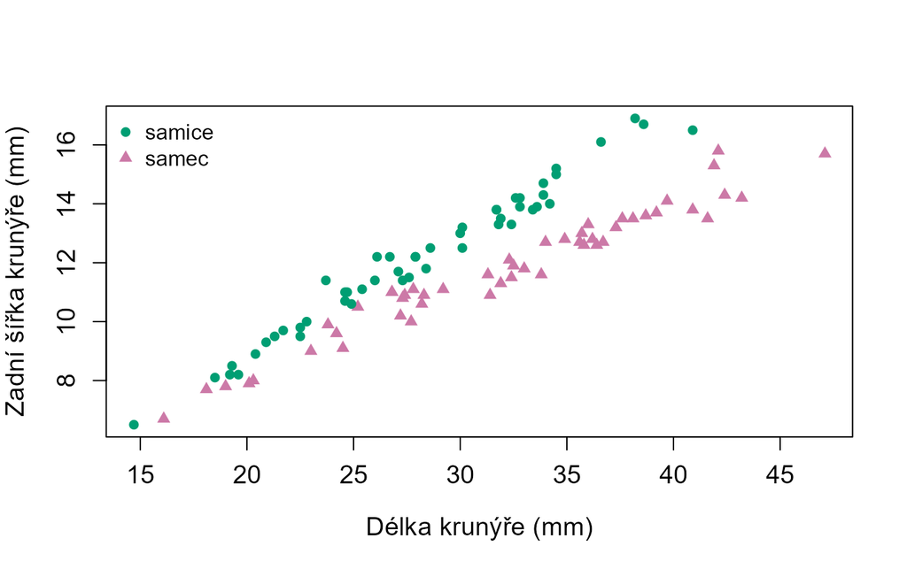

```r
# Barvy a symboly přiřazujeme v celé lekci stejným skupinám
vec_barvy_pohlavi <-
  c(samice = "#009E73", samec = "#CC79A7")
vec_symboly_pohlavi <-
  c(samice = 16, samec = 17)

# Jeden bod představuje jednoho změřeného kraba
plot(
  x = data_krabi$delka_krunyre_mm,
  y = data_krabi$zadni_sirka_mm,
  col = vec_barvy_pohlavi[as.character(data_krabi$pohlavi)],
  pch = vec_symboly_pohlavi[as.character(data_krabi$pohlavi)],
  xlab = "Délka krunýře (mm)",
  ylab = "Zadní šířka krunýře (mm)",
  cex.axis = 1.2,
  cex.lab = 1.2
)
legend(
  x = "topleft",
  legend = names(vec_barvy_pohlavi),
  col = vec_barvy_pohlavi,
  pch = vec_symboly_pohlavi,
  bty = "n"
)
```

**QuestionCo vidíte v grafu?**

Když se pohybujete zleva doprava, co se děje se zadní šířkou? Vypadají oba soubory bodů, jako by měly stejný sklonParametr lineárního modelu udávající, o kolik se v průměru liší odezva dvou pozorování, jejichž prediktor se liší o jednu jednotku (při stejných hodnotách ostatních prediktorů).?

**DůležitéMožná odpověď**

Body naznačují rostoucí vztah u obou pohlaví. Samice mají při podobné délce obvykle větší zadní šířku, ale samotný pohled na body zatím nestačí k přesnému vyčíslení, zda se tento rozdíl s délkou mění.

## 7 Rovnoběžné přímky předpokládají společný sklon

Začneme známým aditivním modelemModel s více prediktory bez interakce: příspěvky prediktorů se sčítají, takže vztah odezvy k jednomu prediktoru je stejný při všech hodnotách ostatních.. Oba prediktoryProměnná, pomocí níž vysvětlujeme variabilitu odezvy; v notaci y ~ x je prediktor x. v něm mohou měnit odhadnutou šířku, ale **sklonParametr lineárního modelu udávající, o kolik se v průměru liší odezva dvou pozorování, jejichž prediktor se liší o jednu jednotku (při stejných hodnotách ostatních prediktorů). vůči délce je pro obě pohlaví společný**.

```r
# Aditivní model připouští posun mezi skupinami, ale stejný sklon
mod_rovnobezne <-
  lm(
    formula = zadni_sirka_mm ~ delka_krunyre_mm + pohlavi,
    data = data_krabi
  )
coef(object = mod_rovnobezne)
```

```
     (Intercept) delka_krunyre_mm     pohlavisamec
        2.819657         0.331590        -1.717180
```

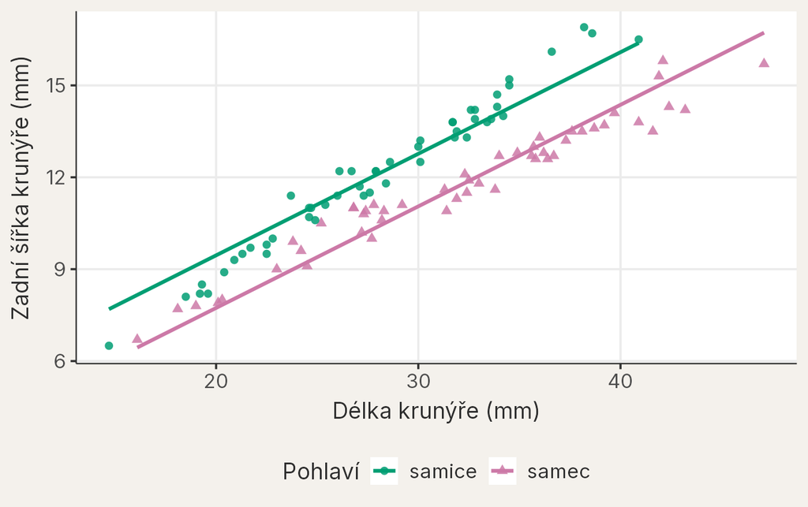

**QuestionCo predikuje aditivní model?**

Co by tento model predikoval o rozdílu v zadní šířce mezi stejně dlouhými kraby u kratších a delších délek z pozorovaného rozsahu?

**DůležitéMožná odpověď**

Přímky zůstávají rovnoběžné, takže predikovaný rozdíl je v obou případech stejný. Je to vlastnost modelu, kterou jsme do něj vložili znakem `+`, ne výsledek samostatného testu této vlastnosti.

## 8 Mění se rozdíl mezi samicemi a samci s délkou krunýře?

V bodovém grafuGraf vztahu dvou numerických proměnných, v němž každý bod představuje jedno pozorování a jeho dvě hodnoty určují polohu na osách. se rozdíl mezi skupinami při různých délkách nemusí jevit jako stálý. Na stejné osy proto můžeme orientačně vést přímku každou skupinou zvlášť. Srovnejte jejich směr s rovnoběžnými přímkami předchozího obrázku; body krabů jsou v obou grafech stejné.

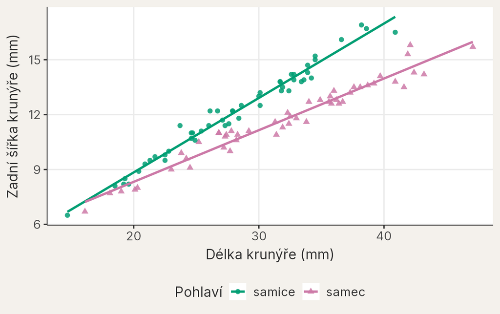

**QuestionPředpovězte tvar**

Pokud mají samice při určité společné délce větší odhadnutou zadní šířku a jejich přímka stoupá rychleji, bude rozdíl mezi přímkami u delších krabů menší, stejný, nebo větší?

**DůležitéMožná odpověď**

Rozdíl by byl větší. Dvě různě strmé přímky totiž mění vzájemnou svislou vzdálenost s délkou.

Když se svislá vzdálenost přímek mění s délkou, závisí vztah délky a šířky na pohlaví. Této závislosti říkáme interakce prediktorůSituace, kdy efekt jednoho prediktoru na odezvu závisí na hodnotě jiného prediktoru.. Stejnou myšlenku můžeme vyjádřit jedním modelem, který oba sklonyParametr lineárního modelu udávající, o kolik se v průměru liší odezva dvou pozorování, jejichž prediktor se liší o jednu jednotku (při stejných hodnotách ostatních prediktorů). odhadne společně.

## 9 Model s interakcí dovoluje samicím a samcům různé sklony

Předchozí obrázek ukázal, proč zkusit model se dvěma různými sklonyParametr lineárního modelu udávající, o kolik se v průměru liší odezva dvou pozorování, jejichž prediktor se liší o jednu jednotku (při stejných hodnotách ostatních prediktorů).. Délku krunýře v modelu měříme v milimetrech. Zápis `delka_krunyre_mm * pohlavi` dovolí, aby se sklon vůči délce mezi pohlavími lišil. Jednotlivé členy tohoto vzorce rozebereme po konkrétní predikciHodnota odezvy, kterou model odhaduje pro nové pozorování nebo pro zvolenou kombinaci prediktorů, která nebyla mezi daty použitými k odhadu modelu..

```r
# Hvězdička připustí odlišné sklony pro samice a samce
mod_interakce <-
  lm(
    formula = zadni_sirka_mm ~ delka_krunyre_mm * pohlavi,
    data = data_krabi
  )
```

Odhadnuté přímky kreslíme jen v rozsahu délek, které byly v dané skupině opravdu pozorovány. Za konci těchto úseků bychom už extrapolovali.

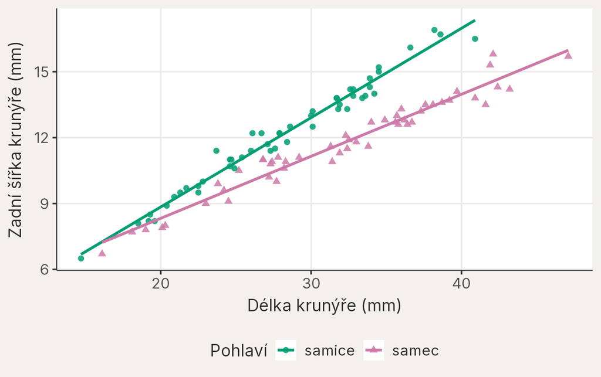

Přímka samic zde stoupá strměji než přímka samců. Čáry ukazují odhadnuté přímky modelu, zatímco body jsou skutečná měření. Svislou vzdálenost přímek vyčíslíme pro jednu společnou délku krunýře.

## 10 Co model predikuje pro stejně dlouhou samici a samce?

V grafu obou přímek můžeme porovnat jejich výšku nad stejným místem vodorovné osy. Zvolíme délku, která leží uvnitř pozorovaného rozsahu samic i samců a snadno ji najdeme na ose. Při srovnání pohlaví tak držíme délku krunýře stejnou.

```r
# Zvolíme společnou délku uvnitř pozorovaného rozsahu obou pohlaví
delka_porovnani_mm <- 30

# Připravíme stejnou délku pro samici i samce
data_porovnani <-
  data.frame(
    delka_krunyre_mm = rep(x = delka_porovnani_mm, times = 2),
    pohlavi = c("samice", "samec")
  )

# Model odhadne šířku pro obě kombinace
data_porovnani$odhad_sirky_mm <-
  predict(
    object = mod_interakce,
    newdata = data_porovnani
  )
data_porovnani
```

```
  delka_krunyre_mm pohlavi odhad_sirky_mm
1               30  samice       12.91000
2               30   samec       11.14947
```

Zvolili jsme **30 mm**. Která přímka je nad touto délkou výše? Obě predikceHodnota odezvy, kterou model odhaduje pro nové pozorování nebo pro zvolenou kombinaci prediktorů, která nebyla mezi daty použitými k odhadu modelu. jsou v grafu označeny prázdnými kruhy. Svislá tečkovaná čára ukazuje místo, kde čteme jejich **svislou vzdálenost**; menší body zůstávají naměřenými kraby.

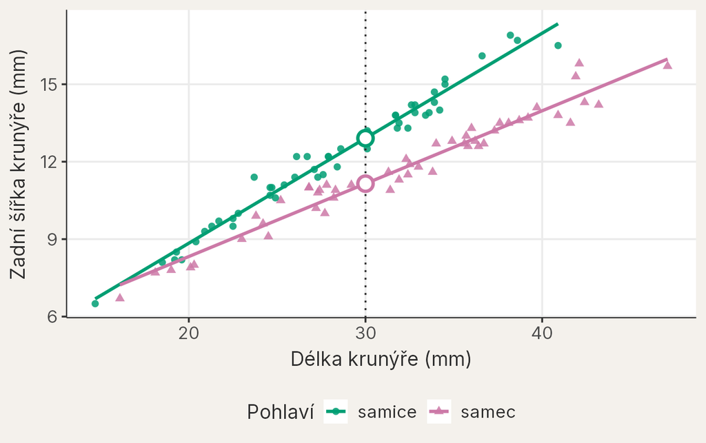

**DůležitéRozdíl při zvolené délce**

Při délce 30 mm model odhaduje zadní šířku samice 12,91 mm a samce 11,15 mm. **Rozdíl samec minus samice je −1,76 mm.** Samčí predikce tedy leží o 1,76 mm níže.

Přímky nemají stejný sklonParametr lineárního modelu udávající, o kolik se v průměru liší odezva dvou pozorování, jejichž prediktor se liší o jednu jednotku (při stejných hodnotách ostatních prediktorů)., a proto se jejich svislá vzdálenost s délkou mění. Koeficienty modelu ukážou, o kolik se tento rozdíl změní při porovnání délek vzdálených o 1 mm.

## 11 Co znamenají koeficienty modelu s interakcí?

Z minulé lekce známe aditivní modelModel s více prediktory bez interakce: příspěvky prediktorů se sčítají, takže vztah odezvy k jednomu prediktoru je stejný při všech hodnotách ostatních. se společným sklonemParametr lineárního modelu udávající, o kolik se v průměru liší odezva dvou pozorování, jejichž prediktor se liší o jednu jednotku (při stejných hodnotách ostatních prediktorů).:

`zadni_sirka_mm ~ delka_krunyre_mm + pohlavi`

Aby se sklon mohl mezi pohlavími lišit, přidáme interakční člen označený dvojtečkou:

`zadni_sirka_mm ~ delka_krunyre_mm + pohlavi + delka_krunyre_mm:pohlavi`

R nabízí pro celý pravý výraz kratší zápis s hvězdičkou:

`zadni_sirka_mm ~ delka_krunyre_mm * pohlavi`

Obecně tedy platí `x * y = x + y + x:y`. Výpis `summary()` ukáže čtyři koeficienty: interceptParametr modelu: odhadnutá hodnota odezvy, když jsou všechny numerické prediktory rovny nule a kategoriální prediktory jsou v referenční skupině; geometricky jde o úsek na ose y. a koeficient pro každý ze tří členů na pravé straně. Jde o tentýž model, který nakreslil obě přímky a vytvořil predikceHodnota odezvy, kterou model odhaduje pro nové pozorování nebo pro zvolenou kombinaci prediktorů, která nebyla mezi daty použitými k odhadu modelu. při 30 mm:

```r
summary(object = mod_interakce)
```

```
Call:
lm(formula = zadni_sirka_mm ~ delka_krunyre_mm * pohlavi, data = data_krabi)

Residuals:
     Min       1Q   Median       3Q      Max
-0.92402 -0.34114 -0.01188  0.23472  1.23484

Coefficients:
                              Estimate Std. Error t value Pr(>|t|)
(Intercept)                    0.70771    0.29380   2.409   0.0179 *
delka_krunyre_mm               0.40674    0.01023  39.742  < 2e-16 ***
pohlavisamec                   1.97311    0.40042   4.928 3.47e-06 ***
delka_krunyre_mm:pohlavisamec -0.12445    0.01317  -9.450 2.27e-15 ***
---
Signif. codes:  0 '***' 0.001 '**' 0.01 '*' 0.05 '.' 0.1 ' ' 1

Residual standard error: 0.4241 on 96 degrees of freedom
Multiple R-squared:  0.9664,    Adjusted R-squared:  0.9654
F-statistic: 921.2 on 3 and 96 DF,  p-value: < 2.2e-16
```

V tabulce **Coefficients** jsou čtyři řádky. Sloupec **Estimate** obsahuje odhadyČíslo vypočtené z pozorovaných dat jako přiblížení neznámé vlastnosti nebo parametru; jiný srovnatelný výběr může dát jiný odhad. v milimetrech nebo v milimetrech šířky na milimetr délky. Referenční skupinouÚroveň kategoriálního prediktoru, vůči které model vyjadřuje rozdíly ostatních skupin; její průměr (při nulových numerických prediktorech) je intercept. jsou samice, protože jsme je při tvorbě faktoru `pohlavi` uvedli jako první.

- **`(Intercept)`**, tedy intercept, je odhad zadní šířky **samice s délkou krunýře 0 mm**: 0,708 mm. Takto malého kraba jsme neměřili; číslo samo o sobě biologicky nevykládáme.
- **`delka_krunyre_mm`** je sklon **samičí** přímky: při délce o 1 mm větší model odhaduje šířku větší o 0,407 mm. Nejde o růst jednoho kraba v čase, ale o porovnání různě dlouhých jedinců.
- **`pohlavisamec`** je rozdíl **samec minus samice při délce 0 mm**: +1,973 mm. Není to rozdíl mezi pohlavími při každé délce ani odhad pro některého ze změřených krabů.
- **`delka_krunyre_mm:pohlavisamec`** je interakční člen: rozdíl **sklon samce minus sklon samice**, −0,124 mm/mm. Záporná hodnota říká, že samčí přímka stoupá pomaleji.

**TipDoplňující: proč s interakcí ponecháváme i oba hlavní efekty**

Hvězdička rozvine model na `delka_krunyre_mm + pohlavi + delka_krunyre_mm:pohlavi`. První dva členy určují referenční přímku a rozdíl mezi skupinami v referenční hodnotě délky; poslední člen popisuje rozdíl sklonů. Tomuto uspořádání se říká hierarchický princip modeluPravidlo, že model s interakcí má obsahovat i hlavní efekty všech prediktorů, které v interakci vystupují..

Kdybychom hlavní efektČlen modelu pro jeden prediktor samotný (např. x1 v y ~ x1 * x2); v modelu s interakcí popisuje efekt prediktoru v referenční situaci druhého prediktoru. délky nebo pohlaví bez věcného důvodu odstranili, interakční koeficient by zůstal bez přirozeného základu, vůči kterému se interpretuje. Výjimky existují pro úzce formulované modely, ale v úvodní analýze ponecháváme oba hlavní efekty a biologickou otázku čteme z jejich společných predikcí.

Hodnota 0 mm určuje pouze to, co v tomto zápisu znamenají dva koeficienty. Pro srovnání skutečně měřených délek použijeme oba koeficienty sklonu a dosadíme délku z pozorovaného rozsahu. **Rozdíl −1,76 mm jsme už odečetli z predikcí při 30 mm.** Následující výpočet nepřináší nový výsledek; ukazuje, jak se stejná hodnota sestaví ze čtyř řádků tabulky **Coefficients**. Odhad šířky samice a rozdíl **samec minus samice** mají tuto stavbu:

$$\begin{aligned}
\text{odhad šířky samice při zvolené délce}
&= \text{odhad šířky samice při 0 mm} \\
&\quad + \text{zvolená délka}\times\text{samičí sklon} \\
\text{rozdíl samec minus samice při zvolené délce}
&= \text{rozdíl při 0 mm} \\
&\quad + \text{zvolená délka}\times\text{rozdíl sklonů}
\end{aligned}$$

Při 30 mm dosadíme odhady z tabulky **Coefficients**:

$$\begin{aligned}
\text{odhad šířky samice}
&= \text{0,7077}
+ 30\cdot \text{0,4067}
\approx \text{12,91}\,\text{mm} \\
\text{rozdíl samec minus samice}
&= \text{1,9731}
+ 30\cdot (\text{−0,1245})
\approx \text{−1,76}\,\text{mm}
\end{aligned}$$

Ve výpočtu používáme nezaokrouhlené koeficienty modelu; zobrazená čtyři desetinná místa jsou jen pro čitelnost. Po vynásobení se výpočet zkrátí na dva součty:

$$\begin{aligned}
\text{odhad šířky samice}
&\approx \text{0,7077}
+ \text{12,2023}
\approx \text{12,91}\,\text{mm} \\
\text{rozdíl samec minus samice}
&\approx \text{1,9731}
+ (\text{−3,7336})
\approx \text{−1,76}\,\text{mm}
\end{aligned}$$

Stejný postup lze zapsat stručně pro libovolnou délku:

$$\begin{aligned}
\hat{y}_{\mathrm{samice}}(x) &= \beta_0 + \beta_1 x \\
\hat{y}_{\mathrm{samec}}(x)-\hat{y}_{\mathrm{samice}}(x) &= \beta_2 + \beta_3 x
\end{aligned}$$

Zde $x$ znamená zvolenou délku krunýře v mm a $\hat{y}$ modelový odhad zadní šířky v mm. $\beta_0$ je řádek `(Intercept)` pro samici při 0 mm, $\beta_1$ její sklon, $\beta_2$ řádek `pohlavisamec` pro rozdíl při 0 mm a $\beta_3$ interakční řádek pro rozdíl sklonů.

Odhad šířky samce získáme přičtením druhého výsledku k prvnímu: 12,91 + (−1,76) = 11,15 mm. To souhlasí s řádkem samce v tabulce predikcí. Pro biologické porovnání čteme **predikce při konkrétní délce** a jejich rozdíl.

Samčí sklon získáme sečtením samičího sklonu a interakčního koeficientu. Vyjde 0,282 mm/mm oproti 0,407 mm/mm u samic. Rozdíl **samec minus samice** se při porovnání o 1 mm delších krabů změní o −0,124 mm. Pro tento rozdíl sklonů získáme z téhož modelu 95% interval spolehlivostiRozsah hodnot vypočtený z dat postupem, který při opakovaných výběrech pokryje skutečnou hodnotu parametru ve zvoleném podílu případů (typicky 95 %).:

```r
# Interval patří rozdílu sklonů samce a samice
confint(
  object = mod_interakce,
  parm = "delka_krunyre_mm:pohlavisamec"
)
```

```
                                   2.5 %     97.5 %
delka_krunyre_mm:pohlavisamec -0.1505977 -0.0983116
```

Odhadovaný rozdíl sklonů je −0,124 mm/mm; interval sahá od −0,151 do −0,098 mm/mm. Popisuje nejistotuRozsah, v němž nevíme přesnou hodnotu parametru kvůli omezenému výběru a výběrové variabilitě; kvantifikuje se pomocí standardních chyb a intervalů spolehlivosti. odhadu při předpokladech modelu, nikoli rozsah šířek jednotlivých krabů.

**UpozorněníKoeficient pohlaví neplatí při každé délce**

Samotný koeficient `pohlavisamec` popisuje rozdíl při **0 mm**, tedy mimo pozorované délky. Při biologickém porovnání vždy uveďte **konkrétní délku** a porovnejte dvě predikce při této délce.

**TipDoplňující: co dalšího ukazuje summary()?**

Sloupec **Std. Error** popisuje nejistotu jednotlivých koeficientů. **t value** a **Pr(>|t|)** slouží k testování, zda by příslušný *podmíněný* koeficient mohl být nulový při předpokladech modelu. Hvězdičky u p-hodnotPravděpodobnost, že bychom při platnosti nulové hypotézy pozorovali data alespoň tak extrémní jako naše skutečná data. nejsou velikostí biologického rozdílu: například test u `(Intercept)` se ptá na nulovou šířku samice při délce 0 mm, což zde není zajímavá biologická otázka.

Část **Residuals** stručně shrnuje odchylky jednotlivých krabů od přímek. **Residual standard error** je residuální směrodatná odchylkaOdhad typické velikosti residuí v jednotkách odezvy; popisuje rozptýlení pozorování kolem hodnot odhadnutých modelem.; popisuje typickou velikost těchto odchylek v milimetrech. Údaje **Multiple R-squared**, **Adjusted R-squared** a **F-statistic** zatím nepotřebujeme k výkladu interakce; k porovnáváníPostup, kterým na stejných datech srovnáváme předem určené kandidátní modely, například pomocí AIC, adjustovaného R² nebo F-testu vnořených modelů. biologicky zdůvodněných modelů se vrátíme v následující lekci.

**TipDoplňující: modelové průměry při zvolené délce pomocí emmeans**

Funkci `emmeans()` znáte z předchozích lekcí. Pracuje se stejným odhadnutým modelem jako naše tabulka predikcí; nastavíme v ní délku krunýře na 30 mm.

```r
# Odhadneme průměrnou zadní šířku obou pohlaví při zvolené délce
prumery_sirka <-
  emmeans::emmeans(
    object = mod_interakce,
    specs = ~ pohlavi | delka_krunyre_mm,
    at = list(delka_krunyre_mm = delka_porovnani_mm)
  )
prumery_sirka
```

```
delka_krunyre_mm = 30:
 pohlavi emmean     SE df lower.CL upper.CL
 samice    12.9 0.0630 96     12.8     13.0
 samec     11.1 0.0623 96     11.0     11.3

Confidence level used: 0.95
```

Sloupec `emmean` obsahuje stejné dvě bodové predikce jako naše tabulka z `predict()`. Sloupce `lower.CL` a `upper.CL` vymezují modelový interval pro **průměrnouSoučet hodnot vydělený jejich počtem; nejběžnější míra polohy (střední hodnoty). šířku skupiny**, ne rozsah šířek jednotlivých krabů. Chceme-li interval přímo pro rozdíl **samec minus samice**, vypočteme jej zvlášť:

```r
# Odečteme samičí odhad od samčího odhadu
rozdily_sirka <-
  emmeans::contrast(
    object = prumery_sirka,
    method = "revpairwise"
  )
confint(object = rozdily_sirka)
```

```
delka_krunyre_mm = 30:
 contrast       estimate     SE df lower.CL upper.CL
 samec - samice    -1.76 0.0886 96    -1.94    -1.58

Confidence level used: 0.95
```

Odhad rozdílu odpovídá dříve vypočteným −1,76 mm. **Interval pro rozdíl vzniká z obou predikcí a jejich společné nejistoty**; nelze jej spolehlivě vyčíst jen z překryvu dvou intervalů pro jednotlivé průměry. Způsob výběru krabů stále omezuje, na koho lze výsledek přenést.

## 12 Jak dobře přímky popisují změřené kraby?

Přímky procházejí oběma mračny bodů, ale jednotlivé šířky se od nich odchylují. Pro každého kraba je residuumRozdíl mezi pozorovanou hodnotou odezvy a hodnotou odhadnutou modelem: eᵢ = yᵢ − ŷᵢ. rozdíl mezi naměřenou a odhadnutou šířkouHodnota odezvy, kterou fitovaný model přiřadí pozorování na základě jeho hodnot prediktorů; značí se často ŷ.. Graf residuíDiagnostický bodový graf residuí proti odhadnutým hodnotám (nebo prediktoru); vzor v něm ukazuje na nelinearitu nebo nekonstantní rozptyl. proti odhadnutým hodnotám pomůže odhalit zakřivení nebo změnu rozptyluSoučet čtverců odchylek od průměru dělený n − 1; míra variability dat. Odmocnina rozptylu je směrodatná odchylka., které by dvě přímky nezachytily.

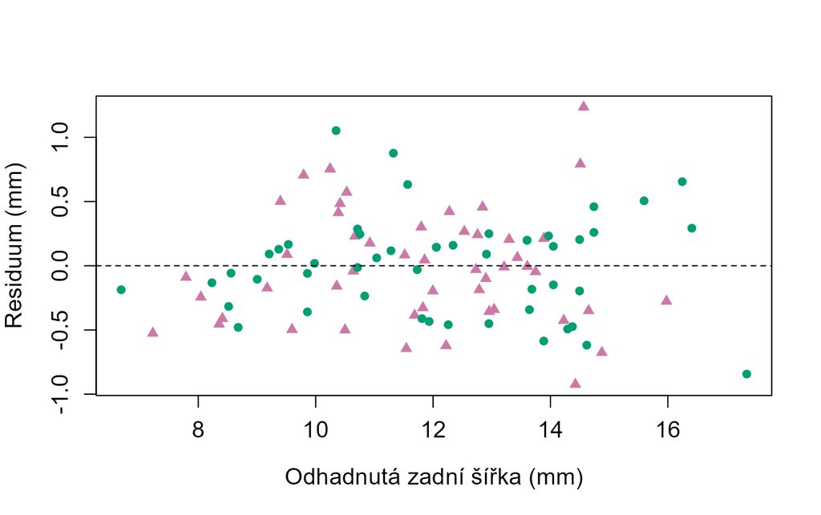

```r
# Spočteme rozdíl mezi měřením a odhadnutou hodnotou pro každého kraba
data_krabi$odhad_sirky_mm <-
  fitted(object = mod_interakce)
data_krabi$residuum_mm <-
  data_krabi$zadni_sirka_mm - data_krabi$odhad_sirky_mm

# Nula znamená dokonalou shodu měření a odhadnuté hodnoty
plot(
  x = data_krabi$odhad_sirky_mm,
  y = data_krabi$residuum_mm,
  col = vec_barvy_pohlavi[as.character(data_krabi$pohlavi)],
  pch = vec_symboly_pohlavi[as.character(data_krabi$pohlavi)],
  xlab = "Odhadnutá zadní šířka (mm)",
  ylab = "Residuum (mm)",
  cex.axis = 1.2,
  cex.lab = 1.2
)
abline(h = 0, lty = 2)
```

Hledáme soustavné zakřivení nebo nápadně větší rozptyl na jedné straně: tím bychom poznali, že dvě přímky některou část vztahu nevystihují. V tomto grafu nic takového nevidíme. Residua leží nad nulou i pod ní v celém rozsahu odhadnutých hodnot, netvoří oblouk a jejich rozptyl je u malých i velkých odhadnutých hodnot podobný. Vraťte se také k bodovému grafuGraf vztahu dvou numerických proměnných, v němž každý bod představuje jedno pozorování a jeho dvě hodnoty určují polohu na osách. a prohlédněte kraby na koncích rozsahu délek. V těchto místech je méně sousedních měření, a jednotlivý krajní bod může sklonParametr lineárního modelu udávající, o kolik se v průměru liší odezva dvou pozorování, jejichž prediktor se liší o jednu jednotku (při stejných hodnotách ostatních prediktorů). přímky více ovlivnit. Takový bod je důvod k ověření měření a citlivosti závěru, ne k automatickému odstranění.

Diagnostika modeluSoubor grafických a numerických kontrol ověřujících, zda jsou rozumně splněny předpoklady modelu: linearita, nezávislost pozorování, konstantní rozptyl a normalita residuí, a zda závěr nestojí na několika vlivných pozorováních. sama nezaručí, že je vztah v populaciCelá množina jednotek nebo širší proces, o kterém chceme pomocí výběru něco zjistit; její vlastnosti (parametry) obvykle neznáme. přesně lineární, že výběrSoubor pozorování, z něhož počítáme statistiky a pomocí něhož se snažíme popsat širší populaci nebo proces. krabů byl reprezentativní, ani že pohlaví něco způsobilo. PredikceHodnota odezvy, kterou model odhaduje pro nové pozorování nebo pro zvolenou kombinaci prediktorů, která nebyla mezi daty použitými k odhadu modelu. mimo pozorované délky jsme nekontrolovali.

**TipDoplňující: interakci můžeme číst jen tam, kde máme data**

Rozdíl sklonů je odhadnut z oblastí, kde máme měření obou pohlaví. Kdyby samice byly pozorovány jen mezi kratšími délkami a samci jen mezi delšími délkami bez společného rozsahu, model by sice dokázal nakreslit dvě přímky, ale jejich srovnání při stejné délce by bylo založeno hlavně na extrapolaciPoužití modelu pro hodnoty prediktoru mimo rozsah pozorovaných dat; tvar vztahu tam nemáme ověřený, a predikce proto může být zavádějící..

Před interpretací interakceSituace, kdy efekt jednoho prediktoru na odezvu závisí na hodnotě jiného prediktoru. proto kontrolujeme nejen počet bodů, ale také **společný rozsah hodnot** a zastoupení všech důležitých kombinací. Řídká nebo prázdná část grafu znamená, že predikce modelu je méně podepřená skutečnými srovnáními. Více parametrů nemůže vytvořit informaci v kombinaci, kterou jsme nepozorovali.

**DůležitéCo ukázal první příklad**

U těchto změřených krabů modré formy roste odhadnutá zadní šířka s délkou u obou pohlaví. Sklon je u samic přibližně 0,407 mm šířky na 1 mm délky a u samců 0,282 mm/mm. Při 30 mm je modelový rozdíl **samec minus samice** −1,76 mm. Samčí sklon je o 0,124 mm/mm menší, takže u krabů s větší délkou model predikuje ještě větší náskok samic. To odpovídá biologickému očekávání z úvodu, že samice s rostoucí velikostí mají relativně širší zadní část krunýře. Jde však o souvislost v těchto měřeních, nikoli o důkaz, že ji způsobuje pohlaví nebo nošení snůšky.

## 13 Liší se rozdíl v délce krunýře mezi pohlavími u obou barevných forem?

Vztah zadní šířky k délce jsme sledovali pouze u modré formy. Soubor obsahuje také oranžovou barevnou formu. U mnoha živočichů se samice a samci liší velikostí a tento rozdíl nemusí být stejný u příbuzných druhů nebo forem. Můžeme se proto zeptat na jiný rozměr týchž krabů: **je rozdíl v délce krunýře mezi samci a samicemi stejný u obou forem?** OdezvouProměnná, jejíž variabilitu se snažíme vysvětlit nebo předpovědět; v notaci modelu y ~ x je odezva y. je tentokrát délka krunýře v milimetrech. Barevná forma i pohlaví jsou kategoriální proměnnéProměnná nabývající hodnot z omezeného počtu kategorií; může být nominální (bez pořadí) nebo ordinální (s pořadím). (znaky); pro tento příklad nepotřebujeme numerický prediktorProměnná, pomocí níž vysvětlujeme variabilitu odezvy; v notaci y ~ x je prediktor x..

**UpozorněníCo tato data o velikosti krabů neřeknou**

Autoři vybrali do každé ze čtyř skupin právě 50 krabů. PrůměrnéSoučet hodnot vydělený jejich počtem; nejběžnější míra polohy (střední hodnoty). délky proto závisejí také na tom, které kraby sesbírali a změřili, nejen na tom, jak velcí krabi dané formy a pohlaví v přírodě obvykle jsou. Příklad nám ukáže, jak číst model se dvěma kategoriálními znaky; tvrzení o velikosti krabů v přírodě by vyžadovalo náhodný výběrSoubor pozorování, z něhož počítáme statistiky a pomocí něhož se snažíme popsat širší populaci nebo proces..

```r
# Ze stejné tabulky vybereme novou odezvu i oba kategoriální znaky
data_formy <-
  data_krabi_vse[, c("sp", "sex", "CL")]
names(data_formy) <-
  c("forma", "pohlavi", "delka_krunyre_mm")

# Obě kategoriální proměnné převedeme na faktory s referenční skupinou
data_formy$forma <-
  factor(
    x = data_formy$forma,
    levels = c("B", "O"),
    labels = c("modrá", "oranžová")
  )
data_formy$pohlavi <-
  factor(
    x = data_formy$pohlavi,
    levels = c("F", "M"),
    labels = c("samice", "samec")
  )

# Počty ve čtyřech skupinách a chybějící délky
table(data_formy$forma, data_formy$pohlavi)
```

```
           samice samec
  modrá        50    50
  oranžová     50    50
```

```r
colSums(x = is.na(data_formy))
```

```
           forma          pohlavi delka_krunyre_mm
               0                0                0
```

```r
summary(object = data_formy$delka_krunyre_mm)
```

```
   Min. 1st Qu.  Median    Mean 3rd Qu.    Max.
  14.70   27.27   32.10   32.11   37.23   47.60
```

V souboru je 200 krabů. V každé ze čtyř kombinací je 50 měření; v délce krunýře chybí 0 hodnot. Pozorované délky v celém souboru sahají od 14,7 do 47,6 mm. Jeden řádek stále představuje jednoho kraba. Názvy forem označují dvě skupiny v datovém souboru, nikoli zásah, který bychom krabům přidělili.

## 14 Jaké délky krunýře vidíme ve čtyřech skupinách?

Podívejte se na jednotlivé naměřené délky; každý bod představuje jednoho kraba. Body samic a samců jsou uvnitř každé barevné formy mírně posunuté do stran, aby se méně překrývaly; barvy a tvary bodů pro pohlaví zůstávají stejné jako v předchozích grafech. Modrý a oranžový kroužek u popisku připomíná barevnou formu.

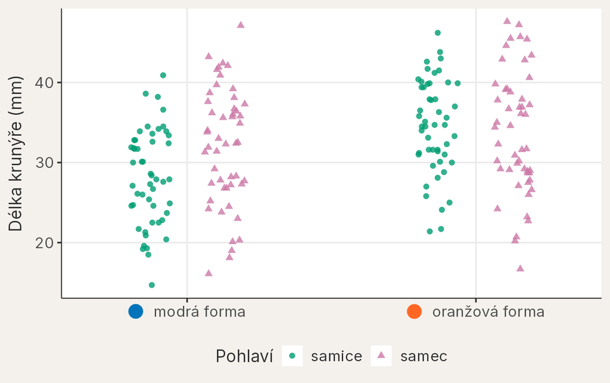

Pozorované průměrné délky krunýře ve čtyřech skupinách.

| Barevná forma | Samice: průměr (mm) | Samec: průměr (mm) |
| --- | --- | --- |
| modrá | 28,10 | 32,01 |
| oranžová | 34,62 | 33,69 |

**QuestionPorovnejte obě formy**

Ve které formě mají samci větší průměrnouSoučet hodnot vydělený jejich počtem; nejběžnější míra polohy (střední hodnoty). délku než samice? Platí to i ve druhé formě?

**DůležitéMožná odpověď**

U modré formy činí rozdíl **samec minus samice** +3,91 mm. U oranžové formy je to −0,93 mm, takže rozdíl má opačný směr.

Průměry popisují skupiny, zatímco jednotlivé body v obrázku připomínají velkou proměnlivost délek mezi kraby uvnitř každé skupiny.

## 15 Jak model zachytí změnu rozdílu mezi pohlavími podle formy?

Vrátíme se ke **stejnému obrázku se všemi jednotlivými kraby**. Body ani osy neměníme. Přidáme pouze velké kosočtverce pro čtyři průměrySoučet hodnot vydělený jejich počtem; nejběžnější míra polohy (střední hodnoty). a v každé barevné formě spojíme průměr samic s průměrem samců. SklonParametr lineárního modelu udávající, o kolik se v průměru liší odezva dvou pozorování, jejichž prediktor se liší o jednu jednotku (při stejných hodnotách ostatních prediktorů). spojnice zde nevyjadřuje spojitou predikciHodnota odezvy, kterou model odhaduje pro nové pozorování nebo pro zvolenou kombinaci prediktorů, která nebyla mezi daty použitými k odhadu modelu.; pouze zvýrazňuje velikost a směr rozdílu mezi dvěma kategoriemi.

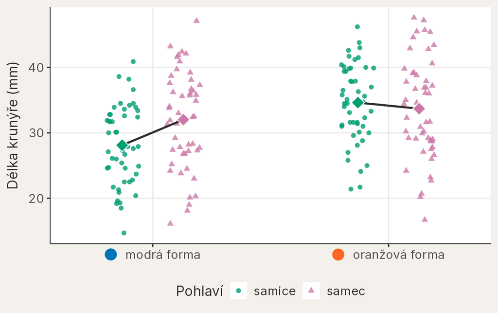

Na modré formě leží průměr samců nad průměrem samic; na oranžové pod ním. Zajímá nás, **o kolik se rozdíl samec minus samice změní mezi formami**. Tento rozdíl dvou rozdílů je druhým typem interakceSituace, kdy efekt jednoho prediktoru na odezvu závisí na hodnotě jiného prediktoru.:

$$\begin{aligned}
\text{změna rozdílu mezi pohlavími}
&= \text{průměr délky oranžových samců} \\
&\quad - \text{průměr délky oranžových samic} \\
&\quad - \text{průměr délky modrých samců} \\
&\quad + \text{průměr délky modrých samic}
\end{aligned}$$

Vezmeme čtyři průměry z tabulky a odečteme vždy dvě hodnoty ze stejného řádku:

$$\begin{aligned}
\text{změna rozdílu mezi pohlavími}
&= (\text{33,688} - \text{34,618}) - (\text{32,014} - \text{28,102}) \\
&= \text{−0,930} - \text{3,912} \\
&= \text{−4,842}\,\text{mm}
\end{aligned}$$

Stručně lze stejné čtyři průměry označit $\bar y_{O,M}$, $\bar y_{O,F}$, $\bar y_{B,M}$ a $\bar y_{B,F}$; $O$ a $B$ označují oranžovou a modrou formu, $M$ a $F$ samce a samici a pruh nad $y$ průměr délky. Pak platí $\Delta = (\bar y_{O,M} - \bar y_{O,F}) - (\bar y_{B,M} - \bar y_{B,F})$, kde $\Delta$ označuje změnu rozdílu mezi pohlavími při přechodu od modré k oranžové formě.

Jediným modelem můžeme tyto čtyři skupinové průměry odhadnout společně. Hvězdička zahrne obě skupiny i jejich interakci:

```r
# Referenční kombinací je modrá forma a samice
mod_formy <-
  lm(
    formula = delka_krunyre_mm ~ forma * pohlavi,
    data = data_formy
  )
summary(object = mod_formy)
```

```
Call:
lm(formula = delka_krunyre_mm ~ forma * pohlavi, data = data_formy)

Residuals:
    Min      1Q  Median      3Q     Max
-16.988  -4.636   0.184   5.130  15.086

Coefficients:
                           Estimate Std. Error t value Pr(>|t|)
(Intercept)                 28.1020     0.9499  29.584  < 2e-16 ***
formaoranžová                6.5160     1.3434   4.851  2.5e-06 ***
pohlavisamec                 3.9120     1.3434   2.912  0.00401 **
formaoranžová:pohlavisamec  -4.8420     1.8998  -2.549  0.01158 *
---
Signif. codes:  0 '***' 0.001 '**' 0.01 '*' 0.05 '.' 0.1 ' ' 1

Residual standard error: 6.717 on 196 degrees of freedom
Multiple R-squared:  0.1232,    Adjusted R-squared:  0.1098
F-statistic: 9.181 on 3 and 196 DF,  p-value: 1.031e-05
```

V tabulce **Coefficients** se opět soustřeďte na sloupec **Estimate**. Řádky nejsou čtyři nezávislé průměry: jeden je referenční průměr a zbylé tři popisují, jak se od něj dostaneme k ostatním skupinám.

## 16 Co znamenají čtyři koeficienty modelu se dvěma kategoriálními znaky?

Protože referenčními skupinamiÚroveň kategoriálního prediktoru, vůči které model vyjadřuje rozdíly ostatních skupin; její průměr (při nulových numerických prediktorech) je intercept. jsou **modrá forma** a **samice**, každý koeficient má přesně určené srovnání. OdhadyČíslo vypočtené z pozorovaných dat jako přiblížení neznámé vlastnosti nebo parametru; jiný srovnatelný výběr může dát jiný odhad. vytáhneme ze stejného modelu, který vytvořil výpis `summary()`.

- **`(Intercept)`** je odhad průměrnéSoučet hodnot vydělený jejich počtem; nejběžnější míra polohy (střední hodnoty). délky **modré samice**: 28,102 mm. Najdete jej v tabulce průměrů v řádku modré formy a sloupci samic.
- **`formaoranžová`** je rozdíl **oranžová minus modrá mezi samicemi**: +6,516 mm. Po přičtení k interceptuParametr modelu: odhadnutá hodnota odezvy, když jsou všechny numerické prediktory rovny nule a kategoriální prediktory jsou v referenční skupině; geometricky jde o úsek na ose y. dostaneme průměr oranžových samic; tento koeficient nepopisuje rozdíl forem u obou pohlaví stejně.
- **`pohlavisamec`** je rozdíl **samec minus samice v modré formě**: +3,912 mm. Souhlasí se svislou vzdáleností obou průměrů u modré formy.
- **`formaoranžová:pohlavisamec`** je změna rozdílu samec minus samice při přechodu **od modré k oranžové formě**: −4,842 mm. Jde přesně o výše vypočtený rozdíl dvou rozdílů, nikoli o další samostatnou skupinu.

```r
# Interval patří k rozdílu dvou rozdílů, ne k jedné skupině
confint(
  object = mod_formy,
  parm = "formaoranžová:pohlavisamec"
)
```

```
                               2.5 %    97.5 %
formaoranžová:pohlavisamec -8.588674 -1.095326
```

Modelový 95% interval spolehlivostiRozsah hodnot vypočtený z dat postupem, který při opakovaných výběrech pokryje skutečnou hodnotu parametru ve zvoleném podílu případů (typicky 95 %). pro změnu rozdílu sahá od −8,59 do −1,10 mm. Celý leží pod nulou: při předpokladech modelu data podporují menší rozdíl samec minus samice u oranžové než u modré formy. Protože autoři vybrali do každé skupiny pevný počet krabů, nelze tento interval automaticky zobecnit na všechny kraby.

Jak model sestaví predikciHodnota odezvy, kterou model odhaduje pro nové pozorování nebo pro zvolenou kombinaci prediktorů, která nebyla mezi daty použitými k odhadu modelu. pro oranžového samce? K odhadu modré samice přidá rozdíl forem mezi samicemi, rozdíl pohlaví u modré formy a změnu tohoto rozdílu u oranžové formy:

$$\begin{aligned}
\text{odhad délky oranžového samce}
&= \text{odhad délky modré samice} \\
&\quad + \text{rozdíl forem mezi samicemi} \\
&\quad + \text{rozdíl pohlaví u modré formy} \\
&\quad + \text{změna rozdílu pohlaví u oranžové formy}
\end{aligned}$$

Dosazené hodnoty jsou právě čtyři řádky výpisu modelu:

$$\begin{aligned}
\text{odhad délky oranžového samce}
&= \text{28,102} + \text{6,516} + \text{3,912} + (\text{−4,842}) \\
&= \text{38,530} + (\text{−4,842}) \\
&= \text{33,688}\,\text{mm}
\end{aligned}$$

V obecném zkráceném zápisu je to $\hat{y}_{O,M}=\beta_0+\beta_1+\beta_2+\beta_3$, kde $\hat{y}_{O,M}$ značí modelový odhad délky oranžového samce. Koeficienty opět číslujeme v pořadí výpisu: $\beta_0$ je řádek `(Intercept)`, tedy referenční průměr modré samice, $\beta_1$ řádek `formaoranžová` (rozdíl forem u samic), $\beta_2$ řádek `pohlavisamec` (rozdíl pohlaví u modré formy) a $\beta_3$ řádek `formaoranžová:pohlavisamec` (změna tohoto rozdílu u oranžové formy).

```r
# Vytvoříme všechny čtyři kombinace a pro každou spočteme odhad
data_kombinace <-
  expand.grid(
    forma = levels(data_formy$forma),
    pohlavi = levels(data_formy$pohlavi)
  )
data_kombinace$delka_odhad_mm <-
  predict(
    object = mod_formy,
    newdata = data_kombinace
  )
data_kombinace
```

```
     forma pohlavi delka_odhad_mm
1    modrá  samice         28.102
2 oranžová  samice         34.618
3    modrá   samec         32.014
4 oranžová   samec         33.688
```

Čtyři odhady z jediného modelu; srovnání pohlaví probíhá uvnitř řádku formy.

| Barevná forma | Samice: odhad (mm) | Samec: odhad (mm) |
| --- | --- | --- |
| modrá | 28,10 | 32,01 |
| oranžová | 34,62 | 33,69 |

V řádku oranžové formy je rozdíl samec minus samice −0,93 mm. Získáme jej také sečtením koeficientů `pohlavisamec` a `formaoranžová:pohlavisamec`: 3,912 + (−4,842) = −0,930 mm. **Samotný koeficient pohlaví tedy platí pro modrou formu; u oranžové se k němu přidá interakce.**

**TipDoplňující: čtyři skupinové predikce pomocí emmeans**

Stejně jako v předchozím příkladu můžeme z již odhadnutého modelu získat predikce pomocí `emmeans()`. Tentokrát žádnou číselnou hodnotu nenastavujeme: žádáme o **obě pohlaví uvnitř každé barevné formy**, tedy o čtyři skutečně zastoupené kombinace.

```r
# Ze stejného modelu získáme odhad pro každou kombinaci formy a pohlaví
prumery_formy <-
  emmeans::emmeans(
    object = mod_formy,
    specs = ~ pohlavi | forma
  )
prumery_formy
```

```
forma = modrá:
 pohlavi emmean   SE  df lower.CL upper.CL
 samice    28.1 0.95 196     26.2     30.0
 samec     32.0 0.95 196     30.1     33.9

forma = oranžová:
 pohlavi emmean   SE  df lower.CL upper.CL
 samice    34.6 0.95 196     32.7     36.5
 samec     33.7 0.95 196     31.8     35.6

Confidence level used: 0.95
```

Sloupec `emmean` ukazuje stejné délky jako tabulka predikcí z `predict()`. Protože model obsahuje obě skupiny i jejich interakci, tyto čtyři odhady jsou zde také rovny pozorovaným průměrům čtyř skupin. Intervaly `lower.CL` a `upper.CL` se vztahují ke **skupinovým průměrům**. Rozdíl **samec minus samice** pro každou formu vypočteme přímo:

```r
# Opačné pořadí dvojice dává rozdíl samec minus samice
rozdily_formy <-
  emmeans::contrast(
    object = prumery_formy,
    method = "revpairwise"
  )
confint(object = rozdily_formy)
```

```
forma = modrá:
 contrast       estimate   SE  df lower.CL upper.CL
 samec - samice     3.91 1.34 196     1.26     6.56

forma = oranžová:
 contrast       estimate   SE  df lower.CL upper.CL
 samec - samice    -0.93 1.34 196    -3.58     1.72

Confidence level used: 0.95
```

Řádek modré formy odpovídá rozdílu +3,91 mm a řádek oranžové −0,93 mm. Interval u každého řádku se týká **rozdílu pohlaví v dané formě**; interval pro změnu tohoto rozdílu mezi formami jsme získali výše z interakčního koeficientu. Tyto tři otázky mají odlišné intervaly, i když vycházejí z téhož modelu.

## 17 Co o jednotlivých krabech čtyři průměry neříkají?

Model čtyř skupin přesně vystihuje jejich průměrySoučet hodnot vydělený jejich počtem; nejběžnější míra polohy (střední hodnoty).. To však neznamená, že stejně dobře vystihuje každého kraba: jednotlivé délky se od skupinových průměrů výrazně liší. Zkontrolujeme proto residuaRozdíl mezi pozorovanou hodnotou odezvy a hodnotou odhadnutou modelem: eᵢ = yᵢ − ŷᵢ. uvnitř skupin; jejich nulový průměr je zde vlastností odhadu skupinových průměrů, nikoli důkazem bezchybného modelu. V houslovém grafuGraf rozdělení numerické proměnné v jedné nebo více skupinách, který zrcadlově kreslí graf hustoty; šířka ‘houslí’ ukazuje, kde jsou hodnoty nahuštěné. (anglicky *violin plot*) širší část naznačuje, kde se odchylky častěji vyskytují, a každý bod ukazuje skutečné měření jednoho kraba.

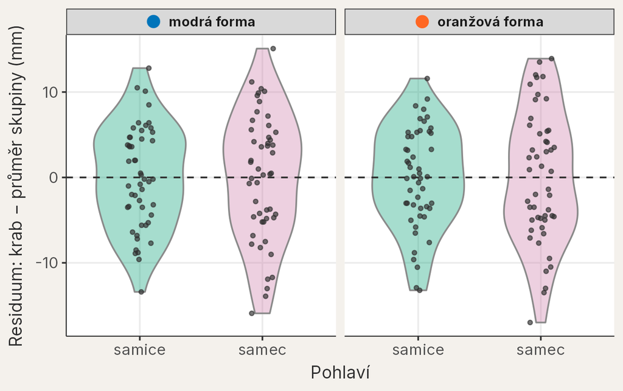

Ve všech skupinách jsou délky na obou stranách odhadu. Rozpětí a krajní hodnoty se mezi skupinami mohou lišit; graf proto nečtěte jako důkaz, že čtyři průměry popisují jednotlivce přesně. Bez popisu způsobu výběru krabů také nelze rozdíly automaticky zobecnit na všechny kraby ani z nich vyvozovat účinek pohlaví nebo barevné formy.

## 18 Přibývá objem dřeva s průměrem kmene stejně rychle u nízkých i vysokých stromů?

V obou příkladech s kraby byl aspoň jeden prediktorProměnná, pomocí níž vysvětlujeme variabilitu odezvy; v notaci y ~ x je prediktor x. skupinou. InterakceSituace, kdy efekt jednoho prediktoru na odezvu závisí na hodnotě jiného prediktoru. však může spojovat i dva numerickéProměnná, jejíž hodnoty jsou čísla se smysluplnou velikostí nebo rozdílem; může být diskrétní, například počet, nebo spojitá, například délka. prediktory. Lesníci odhadují, kolik dřeva je v kmeni, z jeho průměru a z výšky stromu. Podíváme se na měření pokácených stromů střemchy pozdní (*Prunus serotina*), severoamerického stromu, který se v českých lesích šíří jako invazní druh.

**QuestionCo čekáte?**

Představte si dvojici nízkých stromů stejné výšky, z nichž jeden má kmen o 1 cm tlustší, a stejnou dvojici vysokých stromů. O kolik více dřeva má tlustší strom v každé dvojici? Bude tento rozdíl u nízkých i vysokých stromů stejný?

**DůležitéMožná odpověď**

Pravděpodobně ne. Centimetr průměru navíc znamená silnější vrstvu dřeva po celé délce kmene, takže delší kmen jí obsahuje více. Toto očekávání vychází z tvaru kmene, ne z fyziologie stromu. Pokud toto očekávání platí, sklonParametr lineárního modelu udávající, o kolik se v průměru liší odezva dvou pozorování, jejichž prediktor se liší o jednu jednotku (při stejných hodnotách ostatních prediktorů). vztahu objemu a průměru bude záviset na výšce.

Soubor stromy.csv je součástí materiálů lekce; uložte jej do stejné složky `data` jako soubor s kraby. Hodnoty jsou v původních amerických jednotkách: průměr kmene v palcích, výška ve stopách a objem dřeva v krychlových stopách. Proto je hned převedeme:

```r
# Načteme tabulku pokácených stromů
data_stromy <-
  read.csv(file = "data/stromy.csv")

# Převedeme jednotky na cm, m a m³
data_stromy$prumer_cm <-
  data_stromy$Girth * 2.54 # 1 palec = 2,54 cm
data_stromy$vyska_m <-
  data_stromy$Height * 0.3048 # 1 stopa = 0,3048 m
data_stromy$objem_m3 <-
  data_stromy$Volume * 0.0283168 # 1 krychlová stopa = 0,0283168 m³

# Zkontrolujeme typy sloupců, chybějící hodnoty a rozsahy
str(object = data_stromy)
```

```
'data.frame':   31 obs. of  6 variables:
 $ Girth    : num  8.3 8.6 8.8 10.5 10.7 10.8 11 11 11.1 11.2 ...
 $ Height   : int  70 65 63 72 81 83 66 75 80 75 ...
 $ Volume   : num  10.3 10.3 10.2 16.4 18.8 19.7 15.6 18.2 22.6 19.9 ...
 $ prumer_cm: num  21.1 21.8 22.4 26.7 27.2 ...
 $ vyska_m  : num  21.3 19.8 19.2 21.9 24.7 ...
 $ objem_m3 : num  0.292 0.292 0.289 0.464 0.532 ...
```

```r
colSums(x = is.na(data_stromy))
```

```
    Girth    Height    Volume prumer_cm   vyska_m  objem_m3
        0         0         0         0         0         0
```

```r
summary(object = data_stromy[, c("prumer_cm", "vyska_m", "objem_m3")])
```

```
   prumer_cm        vyska_m         objem_m3
 Min.   :21.08   Min.   :19.20   Min.   :0.2888
 1st Qu.:28.07   1st Qu.:21.95   1st Qu.:0.5493
 Median :32.77   Median :23.16   Median :0.6853
 Mean   :33.65   Mean   :23.16   Mean   :0.8543
 3rd Qu.:38.73   3rd Qu.:24.38   3rd Qu.:1.0562
 Max.   :52.32   Max.   :26.52   Max.   :2.1804
```

Jeden řádek představuje **jeden pokácený strom**. Sloupec `Girth` (anglicky obvod) je podle dokumentace ve skutečnosti průměr kmene měřený asi 1,37 m nad zemí. V souboru je 31 stromů a chybí 0 hodnot. Průměr kmene sahá od 21,1 do 52,3 cm, výška od 19,2 do 26,5 m a objem dřeva od 0,29 do 2,18 m³. Vyšší stromy mívají i tlustší kmen (korelaceBezrozměrné číslo popisující směr a těsnost vztahu dvou proměnných; Pearsonova korelace shrnuje lineární vztah a Spearmanova monotónní vztah podle pořadí. průměru a výšky je 0,52); oba prediktory tedy nenesou úplně nezávislou informaci, podobně jako dvě teploty v minulé lekci.

Stromů je málo a dokumentace neuvádí, kde a jak byly vybrány. Závěry proto vztahujeme k těmto 31 stromům a k pozorovaným rozsahům průměru a výšky.

**TipDoplňující: odkud pocházejí data o stromech**

Data pocházejí z knihy Meyer, H. A. (1953): *Forest Mensuration*, Penns Valley Publishers, převzaté do Ryan, T. A., Joiner, B. L. a Ryan, B. F. (1976): *The Minitab Student Handbook*, Duxbury Press. Tabulku šíří základní balíček R `datasets` pod licencí GPL-2 nebo GPL-3; soubor `stromy.csv` je její nezměněná kopie. Stejnou tabulku si můžete vytvořit sami:

```r
# Tabulka je součástí základní instalace R
data_stromy_zdroj <-
  as.data.frame(x = datasets::trees)

# Kontrola: 31 stromů, 3 sloupce a žádné chybějící hodnoty
dim(x = data_stromy_zdroj)
sum(is.na(x = data_stromy_zdroj))

# Uložíme tabulku do složky data jako soubor CSV
write.csv(
  x = data_stromy_zdroj,
  file = "data/stromy.csv",
  row.names = FALSE
)
```

## 19 Vystihne společný sklon nízké i vysoké stromy?

U krabů jsme kreslili jednu přímku pro každé pohlaví. Výška je však číslo a žádné skupiny nemá. Abychom viděli, jak vypadá vztah objemu a průměru u různě vysokých stromů, rozdělíme stromy **jen pro kreslení** do čtyř výškových pásem se zhruba stejným počtem stromů. Každý panel ukazuje stromy jednoho pásma. Do modelu pásma nevstupují: model dál pracuje s výškou jako s číslem.

Začneme známým aditivním modelemModel s více prediktory bez interakce: příspěvky prediktorů se sčítají, takže vztah odezvy k jednomu prediktoru je stejný při všech hodnotách ostatních. z minulé lekce, který má dva numerické prediktoryProměnná, pomocí níž vysvětlujeme variabilitu odezvy; v notaci y ~ x je prediktor x. spojené znakem `+`:

```r
# Aditivní model: jeden společný sklon průměru pro všechny výšky
mod_aditivni <-
  lm(
    formula = objem_m3 ~ prumer_cm + vyska_m,
    data = data_stromy
  )
coef(object = mod_aditivni)
```

```
(Intercept)   prumer_cm     vyska_m
-1.64202494  0.05248820  0.03151742
```

Přímka v každém panelu je predikceHodnota odezvy, kterou model odhaduje pro nové pozorování nebo pro zvolenou kombinaci prediktorů, která nebyla mezi daty použitými k odhadu modelu. modelu pro **střední výšku daného pásma** (mediánHodnota rozdělující seřazená data na dvě stejně početné poloviny; 50% kvantil (prostřední kvartil).: 21,0; 22,9; 24,4; 25,3 m) a vede jen přes průměry kmenů pozorované v tomto pásmu. V pásmech je 9, 7, 8, 7 stromů.

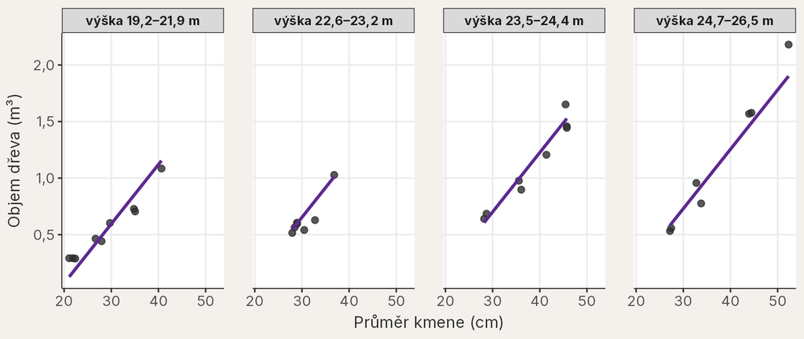

**QuestionCo v panelech vidíte?**

Mají přímky ve všech panelech stejný sklonParametr lineárního modelu udávající, o kolik se v průměru liší odezva dvou pozorování, jejichž prediktor se liší o jednu jednotku (při stejných hodnotách ostatních prediktorů).? Leží body nejnižších a nejvyšších stromů kolem svých přímek stejně?

**DůležitéMožná odpověď**

Přímky jsou rovnoběžné: aditivní model dává všem výškám společný sklon 0,052 m³ na 1 cm průměru. V nejnižším pásmu však tenké kmeny leží nad přímkou a tlusté pod ní, takže body stoupají pozvolněji než přímka. V nejvyšším pásmu je to naopak a body stoupají strměji. Společný sklon tedy zřejmě nevystihuje nízké ani vysoké stromy.

## 20 Model s interakcí dovolí, aby se sklon průměru měnil s výškou

Stejně jako u krabů zapíšeme interakciSituace, kdy efekt jednoho prediktoru na odezvu závisí na hodnotě jiného prediktoru. hvězdičkou. Rozdíl je jen v tom, že druhý prediktorProměnná, pomocí níž vysvětlujeme variabilitu odezvy; v notaci y ~ x je prediktor x. je číslo: interakční člen `prumer_cm:vyska_m` dovolí, aby se **sklonParametr lineárního modelu udávající, o kolik se v průměru liší odezva dvou pozorování, jejichž prediktor se liší o jednu jednotku (při stejných hodnotách ostatních prediktorů). průměru plynule měnil s výškou stromu**.

```r
# Hvězdička dovolí, aby sklon průměru závisel na výšce
mod_stromy <-
  lm(
    formula = objem_m3 ~ prumer_cm * vyska_m,
    data = data_stromy
  )
coef(object = mod_stromy)
```

```
      (Intercept)         prumer_cm           vyska_m prumer_cm:vyska_m
      1.965081588      -0.065283022      -0.120502790       0.004925111
```

Model má opět čtyři koeficienty. Jejich význam rozebereme v další části; nejprve se podíváme, jaké přímky z nich vzniknou.

Na stejné panely nyní nakreslíme přímky modelu s interakcí. Šedá přerušovaná čára opakuje v každém panelu přímku nejnižšího pásma, aby bylo vidět, jak se sklon s výškou mění.

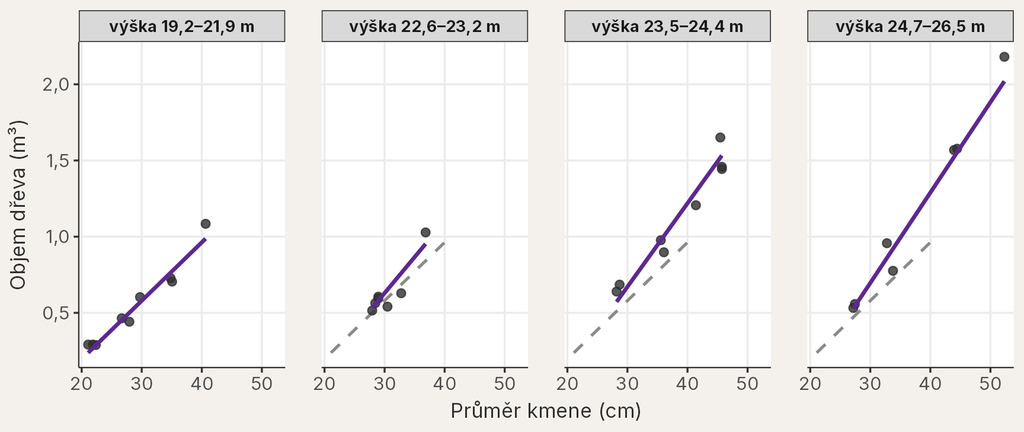

Jak strmá je přímka při určité výšce? Sklon průměru složíme ze dvou koeficientů z výpisu `coef()`, z řádku `prumer_cm` a z interakčního řádku `prumer_cm:vyska_m`:

$$\begin{aligned}
\text{sklon průměru při zvolené výšce}
&= \text{koeficient průměru} \\
&\quad + \text{interakční koeficient} \times \text{zvolená výška}
\end{aligned}$$

Při výšce 21 m dosadíme:

$$\text{sklon průměru} = \text{−0,0653} + \text{0,00493} \cdot 21 \approx \text{0,038}\,\text{m}^3 \text{ na 1 cm}$$

Stručně $\beta_1 + \beta_3 v$, kde $v$ je zvolená výška v metrech. Koeficienty číslujeme v pořadí výpisu: $\beta_0$ je intercept, $\beta_1$ řádek `prumer_cm`, $\beta_2$ řádek `vyska_m` a $\beta_3$ řádek `prumer_cm:vyska_m`. Stejně dostaneme při výškách 21, 23, 25 m sklony 0,038; 0,048; 0,058 m³ na 1 cm. S každým metrem výšky navíc přibude ke sklonu 0,0049 m³ na 1 cm; to je hodnota interakčního koeficientu.

Stejné sklony ukážou i přímé predikceHodnota odezvy, kterou model odhaduje pro nové pozorování nebo pro zvolenou kombinaci prediktorů, která nebyla mezi daty použitými k odhadu modelu.. Zvolíme dva průměry a dvě výšky, které leží uvnitř pozorovaných dat, a pro každou kombinaci spočteme odhad objemu:

```r
# Zvolené průměry a výšky leží uvnitř pozorovaných rozsahů
prumery_porovnani_cm <- c(28, 36)
vysky_porovnani_m <- c(21, 25)

# Každá kombinace průměru a výšky dostane jeden řádek
data_porovnani_stromy <-
  expand.grid(
    prumer_cm = prumery_porovnani_cm,
    vyska_m = vysky_porovnani_m
  )
data_porovnani_stromy$objem_odhad_m3 <-
  predict(
    object = mod_stromy,
    newdata = data_porovnani_stromy
  )
data_porovnani_stromy
```

```
  prumer_cm vyska_m objem_odhad_m3
1        28      21      0.5025637
2        36      21      0.8077182
3        28      25      0.5721650
4        36      25      1.0349230
```

**DůležitéStejný rozdíl v průměru, různý rozdíl v objemu**

Kmen o průměru 36 cm místo 28 cm znamená podle modelu u stromu vysokého 21 m o 0,31 m³ dřeva více, u stromu vysokého 25 m o 0,46 m³ více. Po vydělení 8 cm dostaneme právě sklony průměru při těchto výškách.

## 21 Co znamená koeficient průměru, když se sklon mění s výškou?

Vraťme se ke čtyřem koeficientům z výpisu `coef(object = mod_stromy)`:

- **`(Intercept)`** je odhadČíslo vypočtené z pozorovaných dat jako přiblížení neznámé vlastnosti nebo parametru; jiný srovnatelný výběr může dát jiný odhad. objemu stromu s průměrem 0 cm a výškou 0 m. Takový strom neexistuje; číslo samo o sobě nevykládáme.
- **`prumer_cm`** je sklonParametr lineárního modelu udávající, o kolik se v průměru liší odezva dvou pozorování, jejichž prediktor se liší o jednu jednotku (při stejných hodnotách ostatních prediktorů). průměru **při výšce 0 m**: −0,065 m³ na 1 cm. Záporná hodnota neznamená, že by tlustší kmen měl méně dřeva; platí pro výšku, kterou žádný změřený strom nemá.
- **`vyska_m`** je obdobně sklon výšky **při průměru 0 cm**: −0,121 m³ na 1 m. Ani tento koeficient sám nevykládáme.
- **`prumer_cm:vyska_m`** je interakční člen: o 0,0049 m³ na 1 cm se zvětší sklon průměru, když je strom o 1 m vyšší.

**UpozorněníKoeficient průměru neplatí při každé výšce**

U dvou numerických prediktorůProměnná, pomocí níž vysvětlujeme variabilitu odezvy; v notaci y ~ x je prediktor x. leží hodnota 0 často daleko mimo data. Hlavní koeficient pak popisuje situaci, kterou jsme nepozorovali. Sklon jednoho prediktoru proto vždy uvádíme **při zvolené hodnotě druhého** uvnitř pozorovaného rozsahu.

InterakciSituace, kdy efekt jednoho prediktoru na odezvu závisí na hodnotě jiného prediktoru. lze číst i obráceně. Stejný koeficient říká, o kolik se zvětší sklon výšky (m³ dřeva na 1 m výšky), když je kmen o 1 cm tlustší. U stromu s průměrem 28 cm přibude podle modelu na každý metr výšky 0,017 m³ dřeva, u stromu s průměrem 36 cm 0,057 m³. Obě věty popisují tutéž vlastnost modelu.

Jak přesně interakční koeficient známe, ukáže 95% interval spolehlivostiRozsah hodnot vypočtený z dat postupem, který při opakovaných výběrech pokryje skutečnou hodnotu parametru ve zvoleném podílu případů (typicky 95 %).:

```r
# Interval patří změně sklonu průměru na 1 m výšky
confint(
  object = mod_stromy,
  parm = "prumer_cm:vyska_m"
)
```

```
                        2.5 %      97.5 %
prumer_cm:vyska_m 0.003095651 0.006754571
```

Interval pro změnu sklonu průměru (m³ na 1 cm průměru) při zvýšení stromu o 1 m sahá od 0,0031 do 0,0068. Celý leží nad nulou: při předpokladech modelu tedy data podporují strmější vztah objemu a průměru u vyšších stromů. Platí to pro 31 změřených stromů a v pozorovaném rozsahu průměrů a výšek.

V tomto krátkém příkladu jsme nekontrolovali residuaRozdíl mezi pozorovanou hodnotou odezvy a hodnotou odhadnutou modelem: eᵢ = yᵢ − ŷᵢ. ani vliv jednotlivých stromů, jako jsme to udělali u krabů; 31 stromů je pro takovou kontrolu malý soubor. Objem kmene navíc roste zhruba s druhou mocninou průměru, takže část rozdílu mezi panely by mohl popsat i zakřivený vztah. Přímky zde proto čteme jako jednoduchý popis v pozorovaném rozsahu, ne jako jediný možný model.

## 22 Kdy musíme při výkladu jednoho prediktoru uvést hodnotu druhého?

První příklad vyjádřil interakciSituace, kdy efekt jednoho prediktoru na odezvu závisí na hodnotě jiného prediktoru. jako **změnu rozdílu v šířce mezi pohlavími při různých délkách**: dva sklonyParametr lineárního modelu udávající, o kolik se v průměru liší odezva dvou pozorování, jejichž prediktor se liší o jednu jednotku (při stejných hodnotách ostatních prediktorů). nemusí být stejné. Druhý příklad ji vyjádřil jako **změnu rozdílu v délce mezi pohlavími u dvou barevných forem**: dvě srovnání samce se samicí nemusí dát stejný výsledek. Třetí příklad ji vyjádřil jako **plynulou změnu sklonu průměru s výškou stromu**: s každým metrem výšky je přímka o něco strmější. Ve všech třech případech musíme při výkladu jednoho prediktoruProměnná, pomocí níž vysvětlujeme variabilitu odezvy; v notaci y ~ x je prediktor x. uvést hodnotu nebo úroveň druhého: ptáme se **„při jaké délce?“**, **„v jaké barevné formě?“** nebo **„při jaké výšce?“**.

**TipDoplňující: interakce závisí na škále odezvy**

V příkladech s kraby popisujeme odezvuProměnná, jejíž variabilitu se snažíme vysvětlit nebo předpovědět; v notaci modelu y ~ x je odezva y. v milimetrech, takže interakce znamená změnu **rozdílu** v milimetrech. Jiná biologická otázka se může ptát na poměr: například zda jsou samci v obou formách o stejných 10 % delší než samice. Stejný procentní poměr může při různých průměrechSoučet hodnot vydělený jejich počtem; nejběžnější míra polohy (střední hodnoty). vytvářet různé rozdíly v milimetrech.

Poměry a součiny se na logaritmické škáleŠkála, na níž stejné vzdálenosti odpovídají stejným násobkům (např. 1, 10, 100); hodí se pro hodnoty rozprostřené přes několik řádů a pro násobné vztahy. mění v rozdíly a součty. Příklad se stromy to ukazuje na skutečných datech. Objem kmene je zhruba úměrný druhé mocnině průměru krát výšce, tedy *součinu*. Když objem, průměr i výšku nahradíme jejich logaritmy (transformaceMatematická operace použitá na hodnoty proměnné (např. logaritmus); mění tvar rozdělení i to, jaký vztah model popisuje, například násobný místo součtového., ke které se vrátíme v lekci o tvaru rozdělení), změní se tento součin v součet a model bez interakce by mohl stačit. Interakční koeficient takového modelu má 95% interval spolehlivostiRozsah hodnot vypočtený z dat postupem, který při opakovaných výběrech pokryje skutečnou hodnotu parametru ve zvoleném podílu případů (typicky 95 %). od −1,19 do 1,74. Interval je široký a zahrnuje nulu, takže na logaritmické škále data interakci nedokládají, ačkoli v krychlových metrech ji ukazují zřetelně.

Tvrzení „interakce existuje“ proto není úplné bez uvedení škály modelu. V lekci o binárních a početních odezvách se setkáme s modely, které používají jinou škálu než přímé milimetry; interakční koeficient se pak nejprve interpretuje na této škále modelu a potom pomocí predikcí v biologicky srozumitelných jednotkách.

## 23 Co tedy můžeme říct o krabech a stromech?

Vraťme se k hlavní otázce: **Je rozdíl v zadní šířce krunýře mezi stejně dlouhou samicí a samcem stejný u menších i větších krabů?**

U změřených krabů modré formy není. Zadní šířka roste s délkou u obou pohlaví, ale u samic rychleji: o 0,407 mm na 1 mm délky, u samců o 0,282 mm. Rozdíl samec minus samice se proto mění o −0,124 mm na každý milimetr délky (95% interval spolehlivostiRozsah hodnot vypočtený z dat postupem, který při opakovaných výběrech pokryje skutečnou hodnotu parametru ve zvoleném podílu případů (typicky 95 %). −0,151 až −0,098 mm/mm). Při délce 30 mm má samec podle modelu zadní šířku o 1,76 mm menší než stejně dlouhá samice. Graf residuíDiagnostický bodový graf residuí proti odhadnutým hodnotám (nebo prediktoru); vzor v něm ukazuje na nelinearitu nebo nekonstantní rozptyl. neukázal zakřivení, které by dvě přímky přehlédly.

Výsledek odpovídá biologickému očekávání z úvodu, že samice mají s rostoucí velikostí relativně širší zadní část krunýře. Data však jsou pozorovací a není doloženo, že krabi byli vybráni náhodně: popisují souvislost u těchto 100 krabů a v pozorovaném rozsahu délek, nikoli příčinu. Druhý příklad ukázal, že stejná logika platí pro dvě kategoriální proměnnéProměnná nabývající hodnot z omezeného počtu kategorií; může být nominální (bez pořadí) nebo ordinální (s pořadím).: rozdíl v délce mezi pohlavími byl u oranžové formy o 4,84 mm menší než u modré, ale průměrnéSoučet hodnot vydělený jejich počtem; nejběžnější míra polohy (střední hodnoty). délky závisejí i na tom, které kraby autoři vybrali.

Třetí příklad přenesl stejnou myšlenku na dva numerické prediktoryProměnná, pomocí níž vysvětlujeme variabilitu odezvy; v notaci y ~ x je prediktor x.. U 31 změřených stromů byl vztah objemu a průměru tím strmější, čím byl strom vyšší: při 21 m přidal kmen o 8 cm tlustší podle modelu 0,31 m³ dřeva, při 25 m 0,46 m³. Na původní škále objemu to odpovídá očekávání z tvaru kmene; platí to jen v pozorovaném rozsahu průměrů a výšek.

## 24 Co bude následovat dál

Aditivní modelModel s více prediktory bez interakce: příspěvky prediktorů se sčítají, takže vztah odezvy k jednomu prediktoru je stejný při všech hodnotách ostatních. a model s interakcíSituace, kdy efekt jednoho prediktoru na odezvu závisí na hodnotě jiného prediktoru. jsou dva kandidátní popisy téhož vztahu. Model s interakcí je pružnější, ale má více parametrů a jeho koeficienty se vykládají složitěji. V následující lekci se budeme ptát, jak mezi několika předem biologicky zdůvodněnými modely vybrat ten, který data popisuje dostatečně dobře bez zbytečné složitosti.

## 25 Shrnutí

- Interakce prediktorůSituace, kdy efekt jednoho prediktoru na odezvu závisí na hodnotě jiného prediktoru. znamená, že vztah jednoho prediktoruProměnná, pomocí níž vysvětlujeme variabilitu odezvy; v notaci y ~ x je prediktor x. k odezvěProměnná, jejíž variabilitu se snažíme vysvětlit nebo předpovědět; v notaci modelu y ~ x je odezva y. závisí na hodnotě nebo úrovni druhého; potřebu interakce má podpořit biologická otázka i graf.
- `x * y` je zkratka pro `x + y + x:y`; interakční člen u numerického a kategoriálního prediktoru popisuje rozdíl sklonůParametr lineárního modelu udávající, o kolik se v průměru liší odezva dvou pozorování, jejichž prediktor se liší o jednu jednotku (při stejných hodnotách ostatních prediktorů)..
- Hlavní koeficienty v modelu s interakcí jsou podmíněné: platí při nulové hodnotě druhého prediktoru nebo v referenční skupiněÚroveň kategoriálního prediktoru, vůči které model vyjadřuje rozdíly ostatních skupin; její průměr (při nulových numerických prediktorech) je intercept.. Skupiny proto porovnáváme pomocí predikcíHodnota odezvy, kterou model odhaduje pro nové pozorování nebo pro zvolenou kombinaci prediktorů, která nebyla mezi daty použitými k odhadu modelu. při zvolené hodnotě.
- U dvou kategoriálních prediktorů je interakce rozdíl dvou rozdílů.
- U dvou numerických prediktorů interakce znamená, že se sklon jednoho plynule mění s hodnotou druhého; sklon proto uvádíme při zvolených hodnotách uvnitř dat.
- Závěr omezujeme na pozorovaný rozsah dat, na způsob jejich získání a na souvislost, nikoli příčinu.

### 25.1 Závěrečná otázka

Uveďte biologickou otázku, u které byste čekali, že vztah dvou znaků závisí na skupině nebo na hodnotě jiného znaku. Jak by vypadal graf?

**DůležitéMožné odpovědi**

Například vztah hmotnosti a délky těla u ryb z teplé a studené vody: v teplejší vodě mohou ryby s rostoucí délkou přibírat rychleji, takže přímky by se rozbíhaly. Nebo vztah dávky hnojiva a výnosu u dvou odrůd plodiny, z nichž jedna na hnojivo reaguje silněji. V obou případech by bodový grafGraf vztahu dvou numerických proměnných, v němž každý bod představuje jedno pozorování a jeho dvě hodnoty určují polohu na osách. ukázal dvě skupiny bodů s různým sklonem a aditivní modelModel s více prediktory bez interakce: příspěvky prediktorů se sčítají, takže vztah odezvy k jednomu prediktoru je stejný při všech hodnotách ostatních. s rovnoběžnými přímkami by takový rozdíl nezachytil.

Místo skupiny může vztah měnit i další numerický znak: například růst semenáčků s teplotou může být strmější ve vlhčí půdě. Graf by pak měl několik panelů pro různou vlhkost půdy a přímka růstu proti teplotě by byla s rostoucí vlhkostí strmější.

## Slovníček pojmů

Pojmy použité v těchto materiálech a jejich definice. Úplný průběžně aktualizovaný slovníček je dostupný také [online](https://cuni-natur-biostatistics.github.io/slovnik/).

| term | definition |
| --- | --- |
| aditivni-model | Model s více prediktory bez interakce: příspěvky prediktorů se sčítají, takže vztah odezvy k jednomu prediktoru je stejný při všech hodnotách ostatních. |
| bodovy-graf | Graf vztahu dvou numerických proměnných, v němž každý bod představuje jedno pozorování a jeho dvě hodnoty určují polohu na osách. |
| diagnostika-modelu | Soubor grafických a numerických kontrol ověřujících, zda jsou rozumně splněny předpoklady modelu: linearita, nezávislost pozorování, konstantní rozptyl a normalita residuí, a zda závěr nestojí na něko… |
| extrapolace | Použití modelu pro hodnoty prediktoru mimo rozsah pozorovaných dat; tvar vztahu tam nemáme ověřený, a predikce proto může být zavádějící. |
| graf-residui | Diagnostický bodový graf residuí proti odhadnutým hodnotám (nebo prediktoru); vzor v něm ukazuje na nelinearitu nebo nekonstantní rozptyl. |
| hierarchicky-princip-modelu | Pravidlo, že model s interakcí má obsahovat i hlavní efekty všech prediktorů, které v interakci vystupují. |
| hlavni-efekt | Člen modelu pro jeden prediktor samotný (např. x1 v y ~ x1 * x2); v modelu s interakcí popisuje efekt prediktoru v referenční situaci druhého prediktoru. |
| houslovy-graf | Graf rozdělení numerické proměnné v jedné nebo více skupinách, který zrcadlově kreslí graf hustoty; šířka 'houslí' ukazuje, kde jsou hodnoty nahuštěné. |
| interakce-predikatoru | Situace, kdy efekt jednoho prediktoru na odezvu závisí na hodnotě jiného prediktoru. |
| intercept | Parametr modelu: odhadnutá hodnota odezvy, když jsou všechny numerické prediktory rovny nule a kategoriální prediktory jsou v referenční skupině; geometricky jde o úsek na ose y. |
| interval-spolehlivosti | Rozsah hodnot vypočtený z dat postupem, který při opakovaných výběrech pokryje skutečnou hodnotu parametru ve zvoleném podílu případů (typicky 95 %). |
| kategoricka-promenna | Proměnná nabývající hodnot z omezeného počtu kategorií; může být nominální (bez pořadí) nebo ordinální (s pořadím). |
| korelace | Bezrozměrné číslo popisující směr a těsnost vztahu dvou proměnných; Pearsonova korelace shrnuje lineární vztah a Spearmanova monotónní vztah podle pořadí. |
| linearni-model | Statistický model, v němž je průměrná odezva součtem interceptu a prediktorů násobených koeficienty; lineární je v koeficientech, takže nemusí jít jen o přímku. |
| logaritmicka-skala | Škála, na níž stejné vzdálenosti odpovídají stejným násobkům (např. 1, 10, 100); hodí se pro hodnoty rozprostřené přes několik řádů a pro násobné vztahy. |
| median | Hodnota rozdělující seřazená data na dvě stejně početné poloviny; 50% kvantil (prostřední kvartil). |
| nejistota | Rozsah, v němž nevíme přesnou hodnotu parametru kvůli omezenému výběru a výběrové variabilitě; kvantifikuje se pomocí standardních chyb a intervalů spolehlivosti. |
| numericka-promenna | Proměnná, jejíž hodnoty jsou čísla se smysluplnou velikostí nebo rozdílem; může být diskrétní, například počet, nebo spojitá, například délka. |
| odezva | Proměnná, jejíž variabilitu se snažíme vysvětlit nebo předpovědět; v notaci modelu `y ~ x` je odezva `y`. |
| odhad | Číslo vypočtené z pozorovaných dat jako přiblížení neznámé vlastnosti nebo parametru; jiný srovnatelný výběr může dát jiný odhad. |
| odhadnuta-hodnota | Hodnota odezvy, kterou fitovaný model přiřadí pozorování na základě jeho hodnot prediktorů; značí se často ŷ. |
| opakovana-mereni | Data, kde stejná jednotka (jedinec, lokalita) je měřena opakovaně v čase nebo v různých podmínkách; vytváří korelaci mezi pozorováními. |
| p-hodnota | Pravděpodobnost, že bychom při platnosti nulové hypotézy pozorovali data alespoň tak extrémní jako naše skutečná data. |
| populace | Celá množina jednotek nebo širší proces, o kterém chceme pomocí výběru něco zjistit; její vlastnosti (parametry) obvykle neznáme. |
| porovnani-modelu | Postup, kterým na stejných datech srovnáváme předem určené kandidátní modely, například pomocí AIC, adjustovaného R² nebo F-testu vnořených modelů. |
| predikce | Hodnota odezvy, kterou model odhaduje pro nové pozorování nebo pro zvolenou kombinaci prediktorů, která nebyla mezi daty použitými k odhadu modelu. |
| prediktor | Proměnná, pomocí níž vysvětlujeme variabilitu odezvy; v notaci `y ~ x` je prediktor `x`. |
| promenna | Vlastnost zaznamenaná u pozorování, která může mezi pozorováními nabývat různých hodnot, například druh, délka nebo počet. |
| prumer | Součet hodnot vydělený jejich počtem; nejběžnější míra polohy (střední hodnoty). |
| referencni-skupina | Úroveň kategoriálního prediktoru, vůči které model vyjadřuje rozdíly ostatních skupin; její průměr (při nulových numerických prediktorech) je intercept. |
| residuum | Rozdíl mezi pozorovanou hodnotou odezvy a hodnotou odhadnutou modelem: eᵢ = yᵢ − ŷᵢ. |
| rezidualni-smerodatna-odchylka | Odhad typické velikosti residuí v jednotkách odezvy; popisuje rozptýlení pozorování kolem hodnot odhadnutých modelem. |
| rozptyl | Součet čtverců odchylek od průměru dělený n − 1; míra variability dat. Odmocnina rozptylu je směrodatná odchylka. |
| sklon | Parametr lineárního modelu udávající, o kolik se v průměru liší odezva dvou pozorování, jejichž prediktor se liší o jednu jednotku (při stejných hodnotách ostatních prediktorů). |
| transformace | Matematická operace použitá na hodnoty proměnné (např. logaritmus); mění tvar rozdělení i to, jaký vztah model popisuje, například násobný místo součtového. |
| vyber | Soubor pozorování, z něhož počítáme statistiky a pomocí něhož se snažíme popsat širší populaci nebo proces. |